# 04-quiz-inclass

Charlie Reinhardt

# Quiz 4 In-Class

Complete this quiz in a .Rmd file. To turn in the quiz, push both a .Rmd file and a knitted .html file to your GitHub site.

“All work presented is my own. I have not communicated with or worked with anyone else on this quiz.”

Charlie Reinhardt

Collaboration Reminder: You may not communicate with or work with anyone else on this quiz, but you may use any of our course materials or materials on the Internet.

### Question 1 (20 points).

Examine the alcohol.csv data set that you may have used as an introductory data set in STAT/DATA 234:

```r
library(tidyverse)
library(here)
alcohol_df <- read_csv(here("data/alcohol.csv"))
```

The data set has the following variables on countries throughout the world:

- `country`, the name of the country
- `beer_servings`, the number of beer servings per person per year
- `spirit_servings`, the number of spirit servings per person per year
- `wine_servings`, the number of wine servings per person per year
- `total_litres_of_pure_alcohol`, the number of litres of pure alcohol consumed per person per year

Construct a map of the beer_servings variable. You should choose an appropriate projection and change the default colour scheme of your map.

```r
library(maps)
world_map <- ggplot2::map_data("world")
```

```r
world_df <- left_join(world_map, alcohol_df, by = c("region" = "country"))
```

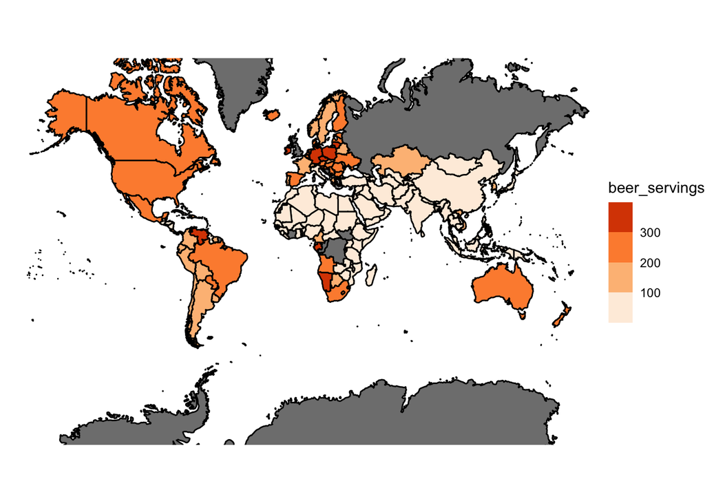

```r
ggplot(data = world_df, mapping = aes(x = long, y = lat, group = group)) +
  geom_polygon(color = "black", aes(fill = beer_servings)) +
  coord_map(projection = "mercator", xlim = c(-180, 180)) +
  theme_void() +
  scale_fill_fermenter(type = "seq", direction = 1, palette = 7)
```

## Question 2 (5 points).

Give an example of a question of interest about the alcohol data where you would want to construct a visualization other than a map to answer the question. What type of visualization would you construct instead?

Are the ‘beer_servings’ and ‘wine_servings’ variables related in each country? Does wine servings increase with beer servings, or does it stay constant, or does it decrease? I would not put this on a map visualization, I would put it on a scatter plot (‘beer_servings’ on one axis and ‘wine_servings’ on the other) and potentially facet the plot by area of the world if it proves to be interesting.